# Visualization Critique

Cam Nguyen

2022-04-24

#### Original Visualization

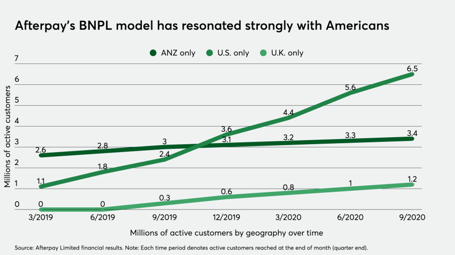

#### Improved Visualization

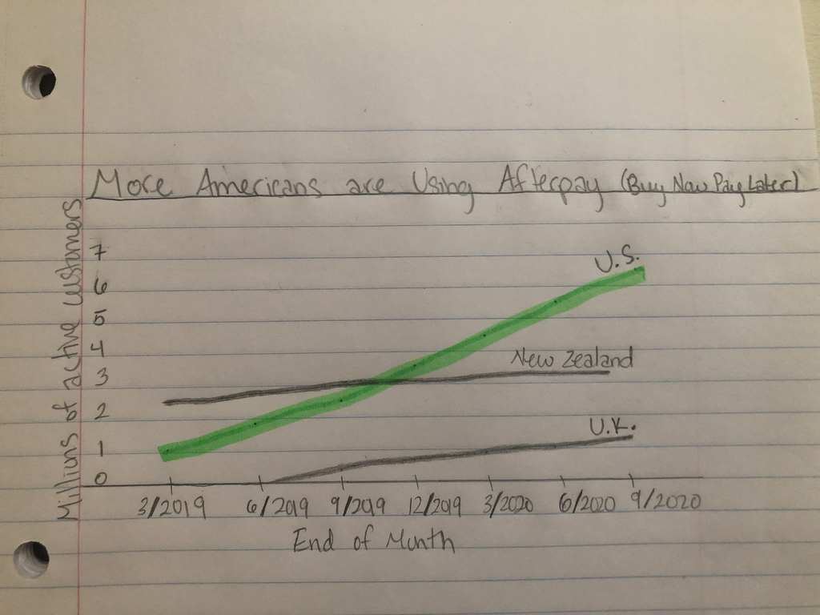

Afterpay is an Australian financial technology company, best known for its buy now, pay later service, that allows users to buy products and pay in installments. The visualization is trying to convey how popular Afterpay has become among Americans. The data displayed is useful and relevant because it shows how the U.S. has the most active users compared to New Zealand and the U.K. U.S.’s data line shows a greater increase in active users as well. Using a line graph is a good choice for the data because it shows the increase of users over time. Overall, the story is conveyed well, but certain details would make the story more obvious. The graph is not misleading because the data is pretty straightforward and shown correctly on the graph. The graph also focuses on active customers which is more accurate information rather than overall customers. An increase in active customers provides evidence that the app is becoming a part of people’s purchasing habits. If the data included all customers, that would include people who might have only used the app once, and that would weaken the story. Therefore, the app did a good job of cutting out unnecessary clutter so that there is a better focus on important data. The graph conveys a simple story, and does not add many distractions, but it could implement visualization principles better. The labeling of the lines is separate from the lines, which makes the viewer do unnecessary work to connect the names to each line and then compare the lines. There is also the use of color in the graph to separate the lines, but the shades of green are difficult to differentiate. My eye is drawn to the center line because it is the darkest and the other two green lines are too similar in color. Therefore, the data line that seems emphasized is New Zealand’s. Other improvements could also be made to the title and by removing the numbers for the data points, because it is unnecessary clutter and distracts from the labeling from the graph lines. The title can be simplified and the acronym BNPL could be unfamiliar to viewers and might confuse them. My improved version implements the Preattentive principles of form and color and Gestalt’s principle of similarity. The U.S. line is highlighted in a bright color and wider than the other lines. The other lines are thinner and grey so that they can be compared to the U.S line, but not stand out. I also moved the labels directly to the data lines. The numbers for the data points were removed because the lines already show the data and important information. There would be too much clutter if the data point numbers were included and the country names were included so close to the data lines. The original ANZ data line label is also confusing, so I spelled out the country name instead. The title is simpler and explains BNPL. The x-axis label is simplified and explains that the points are not only months, but data for the end of each month.